# Data Visualization of Prosper Loans

## by Sheryl Mathias

## Investigation Overview

The goal of this presentation is to understand what factors affect a borrower's APR while lending a loan.

## Univariate Exploration

### Number of loans taken by borrower's Employment Status

```
[Text(0,0,'Employed'),
 Text(0,0,'Full-time'),
 Text(0,0,'Not available'),
 Text(0,0,'Self-employed'),
 Text(0,0,'Other'),
 Text(0,0,'Part-time'),
 Text(0,0,'Not employed'),
 Text(0,0,'Retired')]
```

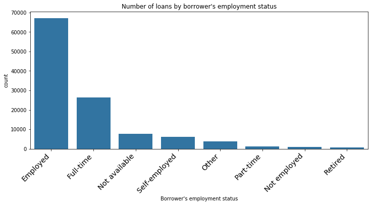

```python
#Bar chart of EmploymentStatus
plt.figure(figsize=(12,5))
base_color = sn.color_palette()[0]
cat_order = prosperLoans['EmploymentStatus'].value_counts().index
chart = sn.countplot(data = prosperLoans, x = 'EmploymentStatus', color = base_color, order = cat_order)
chart.set_title('Number of loans by borrower\'s employment status')
chart.set_xlabel('Borrower\'s employment status')
chart.set_xticklabels(
    chart.get_xticklabels(),
    rotation=45,
    horizontalalignment='right',
    fontweight='light',
    fontsize='x-large')
```

1. It can be seen that maximum number of borrowers (~ 68,000) are employed.
2. There are about 25,000 borrowers who are employed full-time while the least number of borrowers are retired.

## Bivariate Exploration

### Heat map

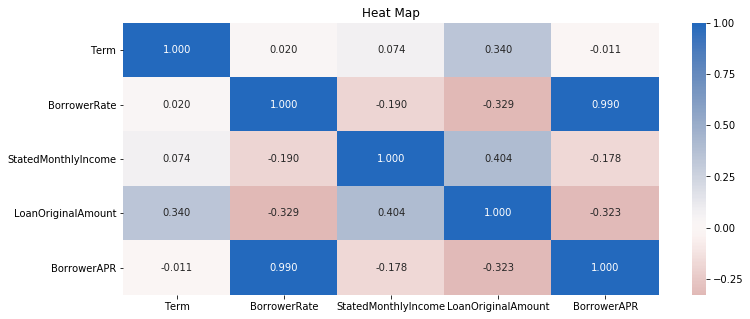

```python
plt.figure(figsize = [12, 5])
sn.heatmap(prosperLoans[numeric_vars].corr(), annot = True, fmt = '.3f',
           cmap = 'vlag_r', center = 0)
plt.title('Heat Map')
plt.show()
```

### Number of loans by borrower's employment status across loan term

```
Text(0.5,0,"Borrower's employment status")
```

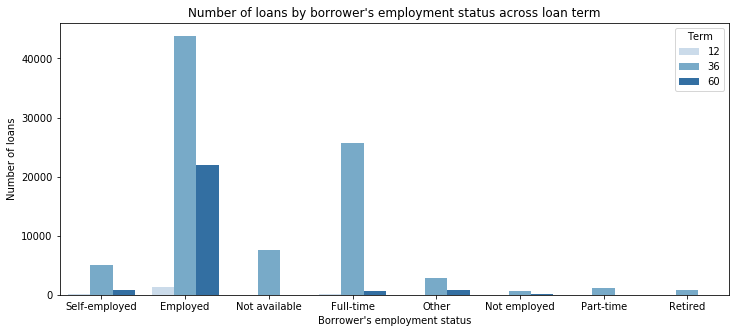

```python
plt.figure(figsize = [12, 5])

#Employment Status vs term
chart = sn.countplot(data = prosperLoans, x = 'EmploymentStatus', hue = 'Term', palette = 'Blues')
chart.set_title('Number of loans by borrower\'s employment status across loan term')
chart.set_ylabel('Number of loans')
chart.set_xlabel('Borrower\'s employment status')
```

1. Maximum number of borrowers were under employed status and had taken 36 month term loan, followed by those with employment status as full time.
2. In every category, it can be observed that 36 month term loan is most common. Most frequently used term for loans borrowed was 36 months by employed and full time borrowers.

### Borrower's original loan amount versus Borrower's APR

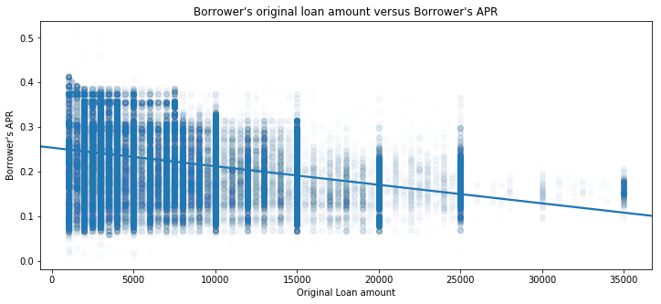

```python
plt.figure(figsize = [12, 5])
chart = sn.regplot(data = prosperLoans, x = 'LoanOriginalAmount', y = 'BorrowerAPR', scatter_kws={'alpha':0.01})
chart.set_title('Borrower\'s original loan amount versus Borrower\'s APR')
chart.set_ylabel('Borrower\'s APR')
chart.set_xlabel('Original Loan amount');
```

1. The range of APR is wider for smaller amounts of loan. This range becomes smaller and the APR reduces with large amounts of loan amount. Thus it can be seen that loan original amount is negatively correlated to Borrower's APR.

### Box Grid

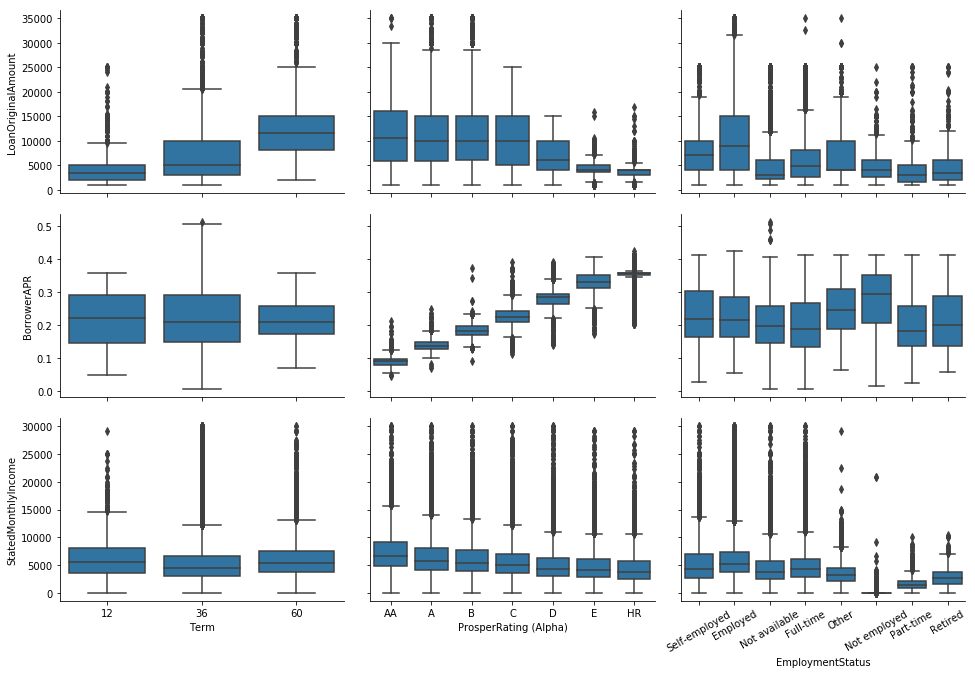

```python
def boxgrid(x, y, **kwargs):
    """ Quick hack for creating box plots with seaborn's PairGrid. """
    default_color = sn.color_palette()[0]
    sn.boxplot(x, y, color = default_color)

plt.figure(figsize = [10, 10])
g = sn.PairGrid(data = prosperLoans, y_vars = ['LoanOriginalAmount', 'BorrowerAPR','StatedMonthlyIncome'],
                x_vars = ['Term','ProsperRating (Alpha)','EmploymentStatus'],
                size = 3, aspect = 1.5)
g.map(boxgrid)
plt.xticks(rotation=30);
plt.show();
```

1. Borrowers lending a large loan amount seem to take a longer loan term.
2. Borrower's APR is higher for those rated lowest by Prosper Loans. (HR) Prosper Loan Rating has an impact on Borrower's APR.
3. Self-employed, employed and full time employed borrowers have a higher monthly income compared to others.

## Multivariate Exploration

### Borrower's Original loan amount versus APR across different loan terms

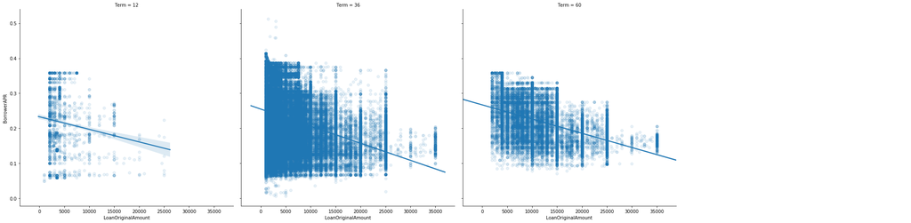

```python
plt.figure(figsize = [12, 5])
g=sn.FacetGrid(data=prosperLoans, aspect=1.0, height=7, col='Term', col_wrap=4)
g.map(sn.regplot, 'LoanOriginalAmount', 'BorrowerAPR', x_jitter=0.05, scatter_kws={'alpha':0.1});
g.add_legend();
```

1. Maximum borrowers took a loan for the term of 36 months.
2. The range of Borrower's APR for the term 36 months is the broadest compared to other loan terms and most of the loan's original amount is between 0 to 10K.
3. We can also see that with larger amounts of the loan, the range of borrower's APR decreases across all loan terms.

### Borrower's Original loan amount versus APR across different Prosper Ratings

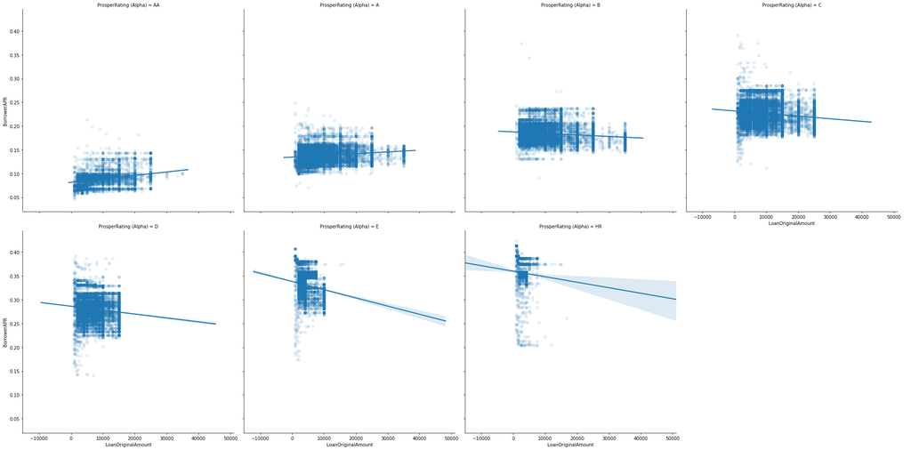

```python
g=sn.FacetGrid(data=prosperLoans, aspect=1.0, height=7, col='ProsperRating (Alpha)', col_wrap=4)
g.map(sn.regplot, 'LoanOriginalAmount', 'BorrowerAPR', x_jitter=0.05, scatter_kws={'alpha':0.1});
g.add_legend();
```

1. It is interesting to see that borrower's APR is less for those rated in the AA category. This keeps increasing as we go through all rating categories. The borrower's APR is the highest for categories D, E and HR.
2. It is also interesting to see that very few borrowers fall in category HR.
3. Maximum borrowers fall in the category A, B, C and D.
4. At the same time as we go through plots for Prosper Rating A, B, C and D, the range of borrower's APR keeps increasing with the maximum range for borrowers categorized with rating HR. The smallest range for APR is for those borrowers categorized in rating AA.

## Conclusion/Summary

1. Borrower's original loan amount and Prosper Loan's rating have an important effect on predicting borrower's APR. This makes sense as the more a borrower borrows from Prosper Loans, the lesser the APR. Borrowers rated less by Prosper Loans are least credible and end up paying more APR compared with those rated really high.
2. As Prosper Loans ratings decreases, the range of borrower's APR increases. This is a possibility as those with less ratings become less credible. Hence they may receive a higher APR.
3. Self-employed, employed and full time employed borrowers have a higher monthly income compared to others.
4. Maximum borrowers prefer a loan term of 36 months followed by 60 months. Borrowers lending a large loan amount seem to take a long loan term.